# forecast-project

Bret Phillips

2025-03-15

# 1 Introduction

## 1.1 Load Required Libraries

```r
library(forecast)
library(lubridate)
library(dplyr)
```

```r
library(ggplot2)
```

## 1.2 Import Data

```r
time_raw <- read.csv("./dataset_for_technical_assessment.csv")
summary(time_raw)
```

```
##  Description              y1                y2                x1
##  Length:157812      Min.   :0.00000   Min.   :0.00000   Min.   :0.0000
##  Class :character   1st Qu.:0.00813   1st Qu.:0.00432   1st Qu.:0.9304
##  Mode  :character   Median :0.00891   Median :0.77574   Median :0.9358
##                     Mean   :0.26355   Mean   :0.49190   Mean   :0.9266
##                     3rd Qu.:0.67769   3rd Qu.:0.79120   3rd Qu.:0.9384
##                     Max.   :1.00000   Max.   :1.00000   Max.   :1.0000
##                     NA's   :74        NA's   :74        NA's   :74
##        x2               x3               x4                x5
##  Min.   :0.0000   Min.   :0.0000   Min.   :0.00027   Min.   :0.0000
##  1st Qu.:0.2137   1st Qu.:0.2503   1st Qu.:0.60902   1st Qu.:0.2282
##  Median :0.4025   Median :0.4618   Median :0.62668   Median :0.2517
##  Mean   :0.3947   Mean   :0.4292   Mean   :0.62260   Mean   :0.2490
##  3rd Qu.:0.5494   3rd Qu.:0.5857   3rd Qu.:0.64024   3rd Qu.:0.2664
##  Max.   :0.9577   Max.   :0.9748   Max.   :0.98216   Max.   :0.4062
##                                    NA's   :70        NA's   :74
##        x6                x7               x8
##  Min.   :0.00000   Min.   :0.1003   Min.   :0.04974
##  1st Qu.:0.02840   1st Qu.:0.6456   1st Qu.:0.22627
##  Median :0.03582   Median :0.6764   Median :0.25199
##  Mean   :0.04493   Mean   :0.6621   Mean   :0.24665
##  3rd Qu.:0.04272   3rd Qu.:0.6902   3rd Qu.:0.27223
##  Max.   :1.00000   Max.   :0.9141   Max.   :1.00000
##  NA's   :74
```

# 2 Data Cleaning and Preprocessing

Above, we see 74 records with NAs. There is no choice about those missing y values; they must be deleted. Any remaining missing on the X’s can be mean-imputed, which appears to affect only one additional record.

## 2.1 Data Cleaning

```r
time_clean <- time_raw |>
     # delete missing y's, impute missing x's
     filter(!is.na(y1)) |>
     filter(!is.na(y2)) |>
     mutate(x1 = ifelse(is.na(x1), mean(x1, na.rm = TRUE), x1)) |>
     mutate(x2 = ifelse(is.na(x2), mean(x2, na.rm = TRUE), x2)) |>
     mutate(x3 = ifelse(is.na(x3), mean(x3, na.rm = TRUE), x3)) |>
     mutate(x4 = ifelse(is.na(x4), mean(x4, na.rm = TRUE), x4)) |>
     mutate(x5 = ifelse(is.na(x5), mean(x5, na.rm = TRUE), x5)) |>
     mutate(x6 = ifelse(is.na(x6), mean(x6, na.rm = TRUE), x6)) |>
     mutate(x7 = ifelse(is.na(x7), mean(x7, na.rm = TRUE), x7)) |>
     mutate(x8 = ifelse(is.na(x8), mean(x8, na.rm = TRUE), x8)) |>
     as.data.frame()

summary(time_clean)
```

```
##  Description              y1                 y2                 x1
##  Length:157738      Min.   :0.000000   Min.   :0.000000   Min.   :0.0000
##  Class :character   1st Qu.:0.008133   1st Qu.:0.004324   1st Qu.:0.9304
##  Mode  :character   Median :0.008906   Median :0.775742   Median :0.9358
##                     Mean   :0.263552   Mean   :0.491896   Mean   :0.9266
##                     3rd Qu.:0.677687   3rd Qu.:0.791200   3rd Qu.:0.9384
##                     Max.   :1.000000   Max.   :1.000000   Max.   :1.0000
##        x2               x3               x4                  x5
##  Min.   :0.0000   Min.   :0.0000   Min.   :0.0002718   Min.   :0.0000
##  1st Qu.:0.2137   1st Qu.:0.2504   1st Qu.:0.6090240   1st Qu.:0.2282
##  Median :0.4027   Median :0.4619   Median :0.6266754   Median :0.2517
##  Mean   :0.3948   Mean   :0.4293   Mean   :0.6226001   Mean   :0.2490
##  3rd Qu.:0.5495   3rd Qu.:0.5857   3rd Qu.:0.6402377   3rd Qu.:0.2664
##  Max.   :0.9577   Max.   :0.9748   Max.   :0.9821589   Max.   :0.4062
##        x6                x7               x8
##  Min.   :0.00000   Min.   :0.1003   Min.   :0.04974
##  1st Qu.:0.02840   1st Qu.:0.6456   1st Qu.:0.22627
##  Median :0.03582   Median :0.6764   Median :0.25198
##  Mean   :0.04493   Mean   :0.6622   Mean   :0.24650
##  3rd Qu.:0.04272   3rd Qu.:0.6902   3rd Qu.:0.27222
##  Max.   :1.00000   Max.   :0.9141   Max.   :1.00000
```

## 2.2 Time Intelligence

Our date-time variable imported as character. This is not useful. We use lubridate to convert it to an actual date-time variable called timestamp. The original character variable is discarded.

```r
time_clean <- time_clean |>
     mutate(timestamp = ymd_hms(Description)) |>
     mutate(day = ymd(substr(Description, start = 1, stop=10))) |>
     mutate(hour = paste("2016-09-30 ", format(timestamp, "%H:%M:%S"))) |>
     mutate(from_start = timestamp - timestamp[1]) |>
     select(-Description)

summary(time_clean$timestamp)
```

```
##                       Min.                    1st Qu.
## "2016-01-01 00:00:00.0000" "2016-05-16 23:51:15.0000"
##                     Median                       Mean
## "2016-09-30 23:12:30.0000" "2016-09-30 22:50:04.8308"
##                    3rd Qu.                       Max.
## "2017-02-14 20:38:45.0000" "2017-07-01 23:55:00.0000"
```

## 2.3 Target Variable Calculation

Observe the plot of y1 and y2 over time.

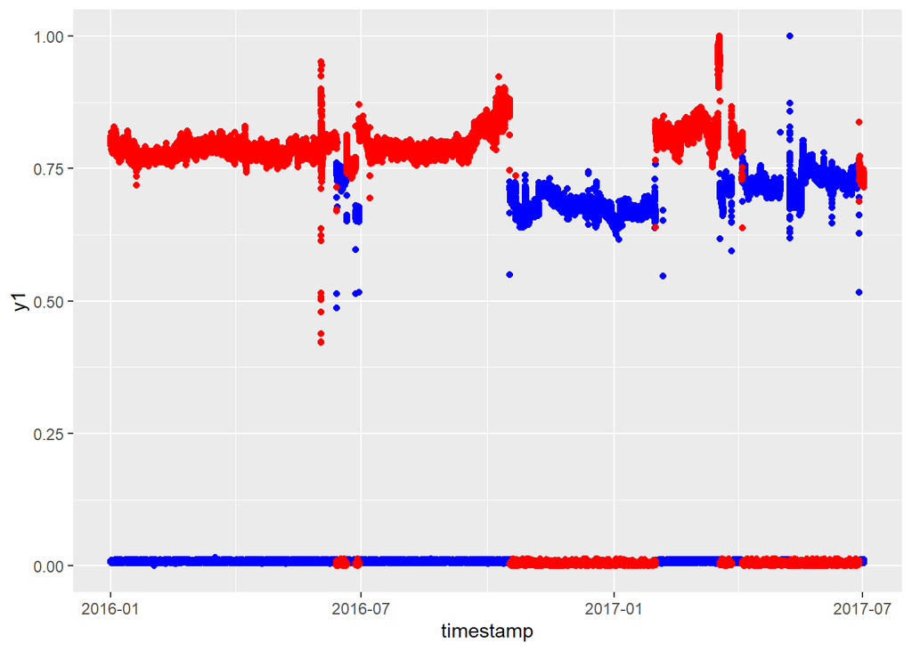

```r
second_series <- tibble(timestamp=time_clean$timestamp, y1=time_clean$y2)

ggplot(time_clean, aes(timestamp, y1))+
     geom_point(data=time_clean, color="blue")+
     geom_point(data=second_series, color="red")
```

```r
time_clean <- time_clean |>
     mutate(y_joint = y1 + y2) |>
     mutate(y1_zero = ifelse(y1 == 0, 1, 0)) |>
     mutate(y2_zero = ifelse(y2 == 0, 1, 0))

summary(time_clean)
```

```
##        y1                 y2                 x1               x2
##  Min.   :0.000000   Min.   :0.000000   Min.   :0.0000   Min.   :0.0000
##  1st Qu.:0.008133   1st Qu.:0.004324   1st Qu.:0.9304   1st Qu.:0.2137
##  Median :0.008906   Median :0.775742   Median :0.9358   Median :0.4027
##  Mean   :0.263552   Mean   :0.491896   Mean   :0.9266   Mean   :0.3948
##  3rd Qu.:0.677687   3rd Qu.:0.791200   3rd Qu.:0.9384   3rd Qu.:0.5495
##  Max.   :1.000000   Max.   :1.000000   Max.   :1.0000   Max.   :0.9577
##        x3               x4                  x5               x6
##  Min.   :0.0000   Min.   :0.0002718   Min.   :0.0000   Min.   :0.00000
##  1st Qu.:0.2504   1st Qu.:0.6090240   1st Qu.:0.2282   1st Qu.:0.02840
##  Median :0.4619   Median :0.6266754   Median :0.2517   Median :0.03582
##  Mean   :0.4293   Mean   :0.6226001   Mean   :0.2490   Mean   :0.04493
##  3rd Qu.:0.5857   3rd Qu.:0.6402377   3rd Qu.:0.2664   3rd Qu.:0.04272
##  Max.   :0.9748   Max.   :0.9821589   Max.   :0.4062   Max.   :1.00000
##        x7               x8            timestamp
##  Min.   :0.1003   Min.   :0.04974   Min.   :2016-01-01 00:00:00.00
##  1st Qu.:0.6456   1st Qu.:0.22627   1st Qu.:2016-05-16 23:51:15.00
##  Median :0.6764   Median :0.25198   Median :2016-09-30 23:12:30.00
##  Mean   :0.6622   Mean   :0.24650   Mean   :2016-09-30 22:50:04.82
##  3rd Qu.:0.6902   3rd Qu.:0.27222   3rd Qu.:2017-02-14 20:38:45.00
##  Max.   :0.9141   Max.   :1.00000   Max.   :2017-07-01 23:55:00.00
##       day                 hour            from_start          y_joint
##  Min.   :2016-01-01   Length:157738      Length:157738     Min.   :0.008513
##  1st Qu.:2016-05-16   Class :character   Class :difftime   1st Qu.:0.716189
##  Median :2016-09-30   Mode  :character   Mode  :numeric    Median :0.784130
##  Mean   :2016-09-30                                        Mean   :0.755448
##  3rd Qu.:2017-02-14                                        3rd Qu.:0.799570
##  Max.   :2017-07-01                                        Max.   :1.617091
##     y1_zero           y2_zero
##  Min.   :0.0e+00   Min.   :0.0e+00
##  1st Qu.:0.0e+00   1st Qu.:0.0e+00
##  Median :0.0e+00   Median :0.0e+00
##  Mean   :6.3e-06   Mean   :6.3e-06
##  3rd Qu.:0.0e+00   3rd Qu.:0.0e+00
##  Max.   :1.0e+00   Max.   :1.0e+00
```

## 2.4 Train-Validation Split

The original exercise calls for using whatever models are dervied on the training data to the next two weeks of data. However, this would require X data from those two weeks and these data were not provided. Therefore, we will hold back the last two weeks of data from our dataset (4032 obs) as our validation sample to satisfy this portion of the assignment.

```r
time_val <- tail(time_clean, n = 4032)

time_train <- setdiff(time_clean, time_val)
```

# 3 Exploratory Data Analysis

There is so much data here, it may be difficult to get a good feel for trends. Thus, I separated the training data into day and time dimensions so the data may be summarized each way to get a better sense of it, before a full ARIMA model is attempted. Time data alone cannot be used as an index for ARIMA models in R, so I append the date 2016-09-30 to all the time values in the hourly data set.

```r
daily <- time_train |>
     group_by(day) |>
     summarize(y_joint = mean(y_joint),
               x1 = mean(x1),
               x2 = mean(x2),
               x3 = mean(x3),
               x4 = mean(x4),
               x5 = mean(x5),
               x6 = mean(x6),
               x7 = mean(x7),
               x8 = mean(x8),
               y1_zero = mean(y1_zero),
               y2_zero = mean(y2_zero))

hourly <- time_train |>
     group_by(hour) |>
     summarize(y_joint = mean(y_joint),
               y2 = mean(y2),
               x1 = mean(x1),
               x2 = mean(x2),
               x3 = mean(x3),
               x4 = mean(x4),
               x5 = mean(x5),
               x6 = mean(x6),
               x7 = mean(x7),
               x8 = mean(x8),
               y1_zero = mean(y1_zero),
               y2_zero = mean(y2_zero))
```

## 3.1 Y1

### 3.1.1 Raw Data

We begin with plotting the Y1 values over time.

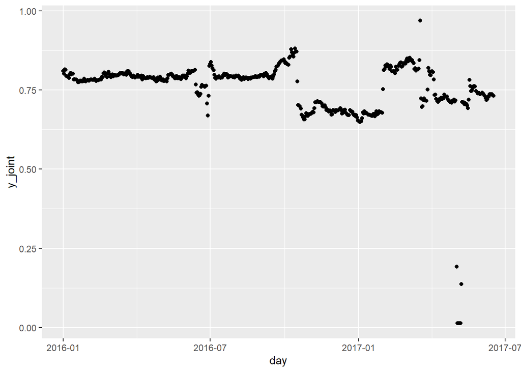

```r
ggplot(daily, aes(x=day, y=y_joint)) +
     geom_point()
```

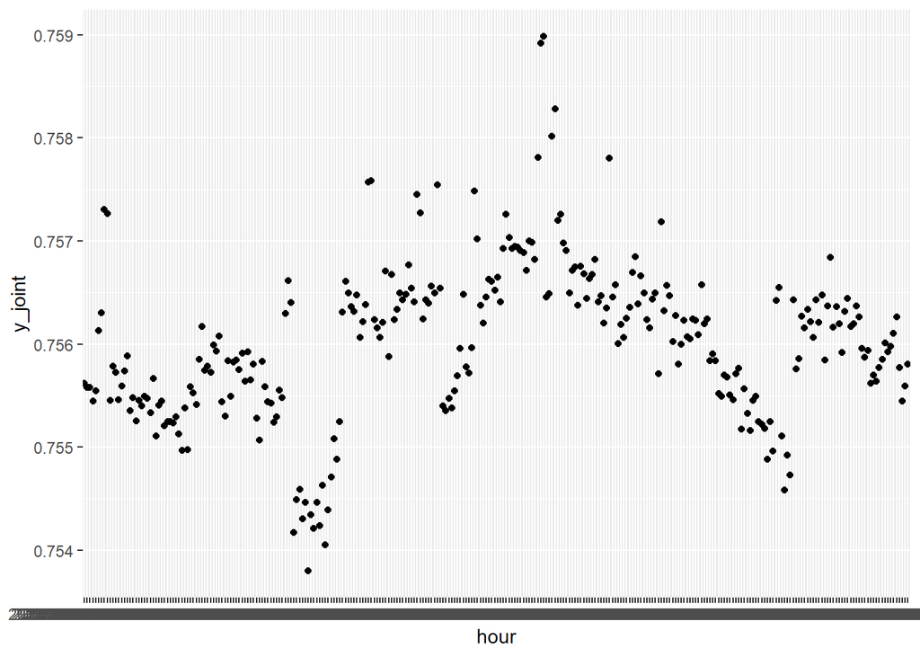

```r
ggplot(hourly, aes(x=hour, y=y_joint)) +
     geom_point()
```

### 3.1.2 ACF and PACF

Now we plot the autocorrelation and partial autocorrelation functions, to get a sense of the error structure of y_joint.

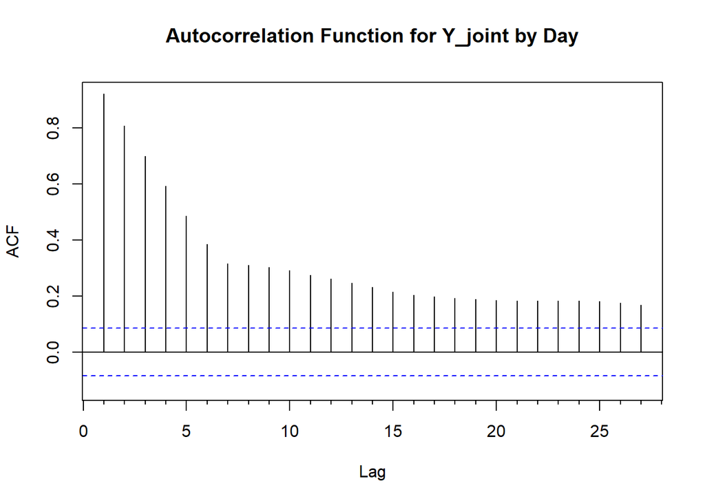

```r
y_day <- ts(daily$y_joint, daily$day)

Acf(x = y_day, main = "Autocorrelation Function for Y_joint by Day")
```

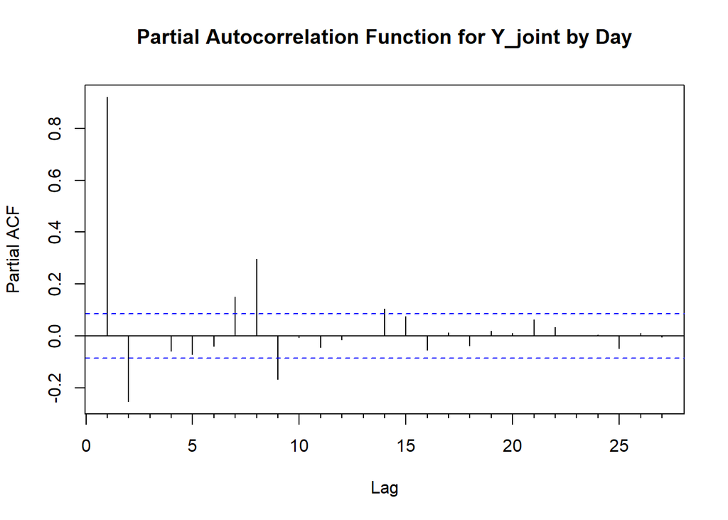

```r
Pacf(x = y_day, main = "Partial Autocorrelation Function for Y_joint by Day")
```

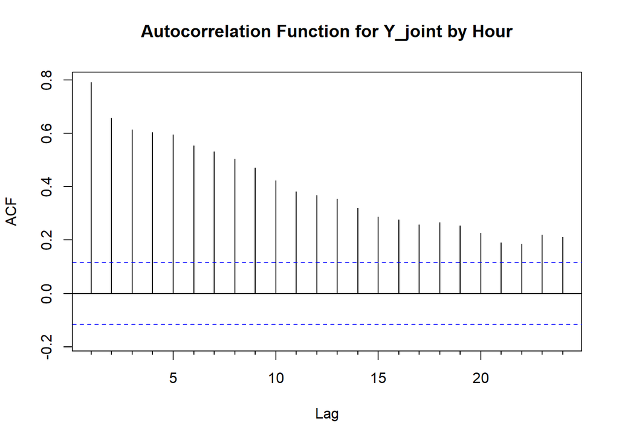

```r
y_hour <- ts(hourly$y_joint, as.POSIXct(hourly$hour))

Acf(x = y_hour, main = "Autocorrelation Function for Y_joint by Hour")
```

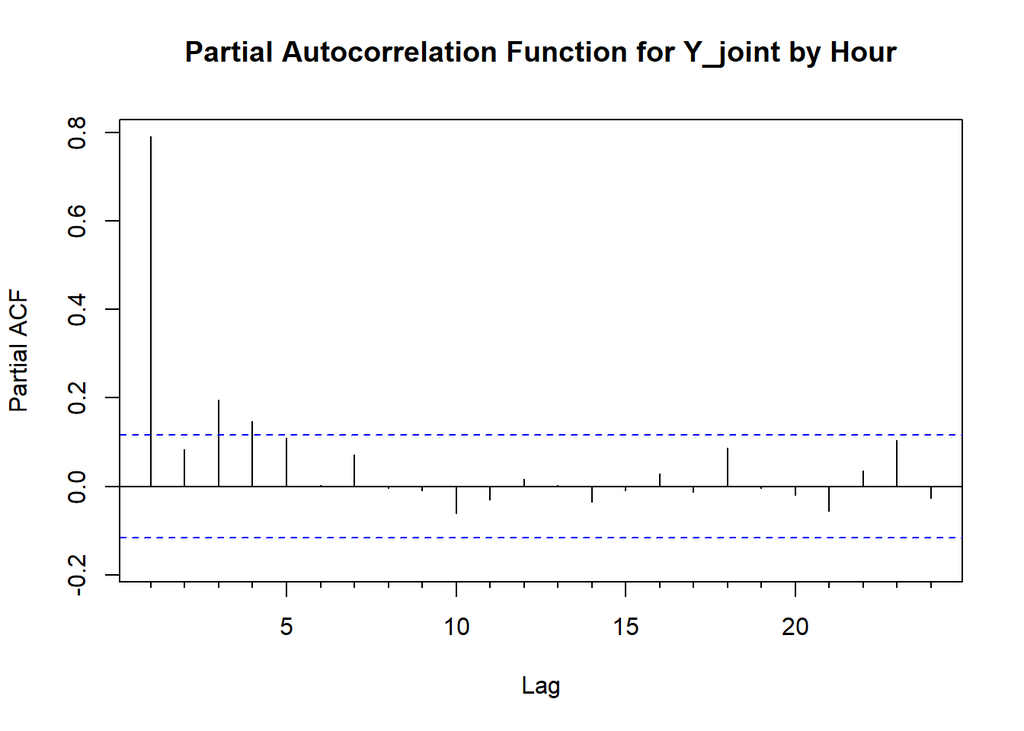

```r
Pacf(x = y_hour, main = "Partial Autocorrelation Function for Y_joint by Hour")
```

The gradual descent of the ACFs show that the data are non-stationary and thus will require differencing. The PACFs for daily data show a spike at lag 1 (at least), indicating the need for AR terms.

# 4 Forecasting

Prep the time series object using the ts function from base R. Also, auto.arima requires that regressors be passed as a matrix object, so we prepare that matrix too.

```r
y_train <- ts(time_train$y_joint, time_train$timestamp)

# also prep predictor matrix, which applies to both models
x_train <- as.matrix(time_train[, c(3:10,16:17)])

# and, of course, we must also do this for the validation data
y_val <- ts(time_val$y_joint, time_val$timestamp)

# also prep predictor matrix for validation for forecasting
x_val <- as.matrix(time_val[, c(3:10,16:17)])
```

## 4.1 Modeling - Y_joint

### 4.1.1 Null Model

To understand the effect of the predictors, we begin with a null model that does not contain predictors.

```r
y_null <- auto.arima(y = y_train)
summary(y_null)
```

```
## Series: y_train
## ARIMA(4,1,5)
##
## Coefficients:
##           ar1      ar2     ar3      ar4      ma1      ma2      ma3     ma4
##       -0.3712  -0.2130  0.0403  -0.1997  -0.0240  -0.1945  -0.2622  0.1041
## s.e.   0.0504   0.0421  0.0400   0.0110   0.0505   0.0398   0.0322  0.0305
##           ma5
##       -0.0719
## s.e.   0.0120
##
## sigma^2 = 9.222e-05:  log likelihood = 495970.6
## AIC=-991921.1   AICc=-991921.1   BIC=-991821.7
##
## Training set error measures:
##                         ME        RMSE         MAE       MPE      MAPE
## Training set -1.700877e-06 0.009602682 0.003829368 -0.169007 0.7457596
##                   MASE         ACF1
## Training set 0.8738119 0.0001238998
```

The auto.arima algorithm included 4 AR and 5 MA terms, which is not surprising given the results of the ACF and PACF plots.

Now we add the regressors into the ARIMA model.

### 4.1.2 Full Model

```r
y_fit <- auto.arima(y = y_train, xreg = x_train)
summary(y_fit)
```

```
## Series: y_train
## Regression with ARIMA(4,1,3) errors
##
## Coefficients:
##           ar1      ar2     ar3      ar4      ma1     ma2      ma3  drift
##       -0.0382  -0.3853  0.1672  -0.0696  -0.3662  0.0784  -0.3951      0
## s.e.   0.1202   0.0600  0.0268   0.0074   0.1203  0.0807   0.0650      0
##           x1      x2       x3      x4       x5      x6       x7      x8
##       0.3839  0.0128  -0.0087  0.7949  -0.0312  0.0962  -0.0806  0.0751
## s.e.  0.0119  0.0027   0.0030  0.0067   0.0071  0.0079   0.0050  0.0040
##       y1_zero  y2_zero
##       -0.0144  -0.0048
## s.e.   0.0071   0.0071
##
## sigma^2 = 6.914e-05:  log likelihood = 518113.7
## AIC=-1036189   AICc=-1036189   BIC=-1036001
##
## Training set error measures:
##                         ME       RMSE         MAE        MPE      MAPE
## Training set -1.406505e-05 0.00831432 0.003089154 -0.0928351 0.6487141
##                   MASE        ACF1
## Training set 0.7049048 7.04206e-05
```

Interestingly, the inclusion of regressors replaced two of the MA terms.

Because the null and full models are of different (p, d, q) orders, a direct comparison of AICs or BICs is not informative. However, we can see that RMSE of the full model is about .0013 lower than that of the null model, indicating that some useful variance is captured by the predictors.

### 4.1.3 Residuals - Full Model

Below we plot the residuals of the full (4, 1, 3) ARIMA model.

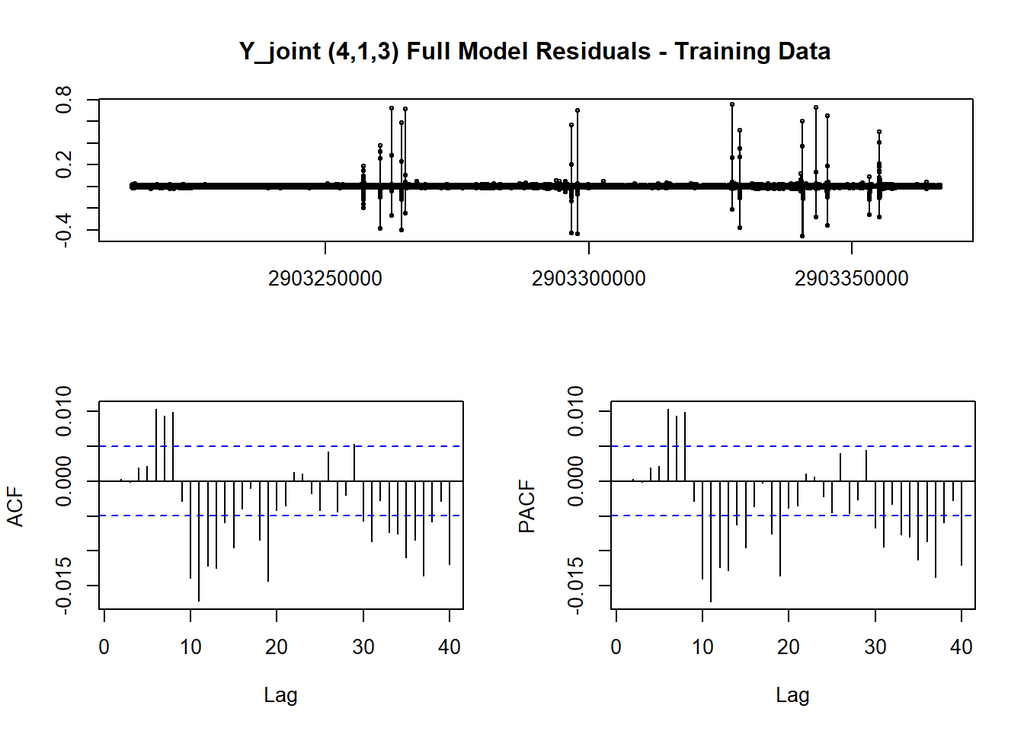

```r
tsdisplay(residuals(y_fit), lag.max = 40, main = "Y_joint (4,1,3) Full Model Residuals - Training Data")
```

### 4.1.4 Forecast for Next 14 Days

As noted above, to complete the next portion of the assignment, we will refer to our validation data. Specifically, the x_val data, which contain our new regressor data.

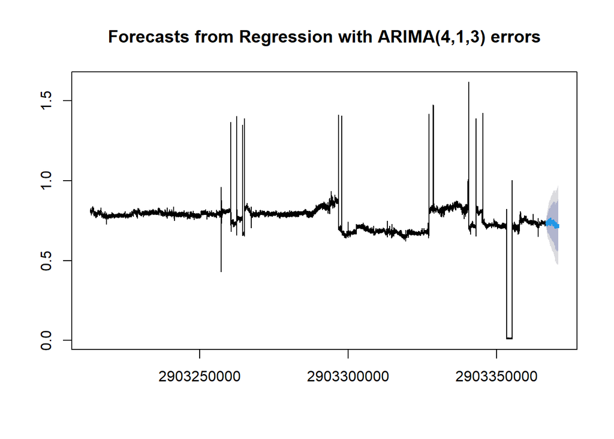

```r
y_fcast <- forecast(y_fit, xreg = x_val)

plot(y_fcast)
```

Forecasting on the validation data looks pretty reasonable.

Let’s examine the distribution of residuals to see what the actual performance of our model was.

```r
time_val$resid <- time_val$y_joint - y_fcast$mean

summary(time_val$resid)
```

```
##      Min.   1st Qu.    Median      Mean   3rd Qu.      Max.
## -0.032587 -0.014078 -0.006168  0.001022  0.014115  0.644437
```

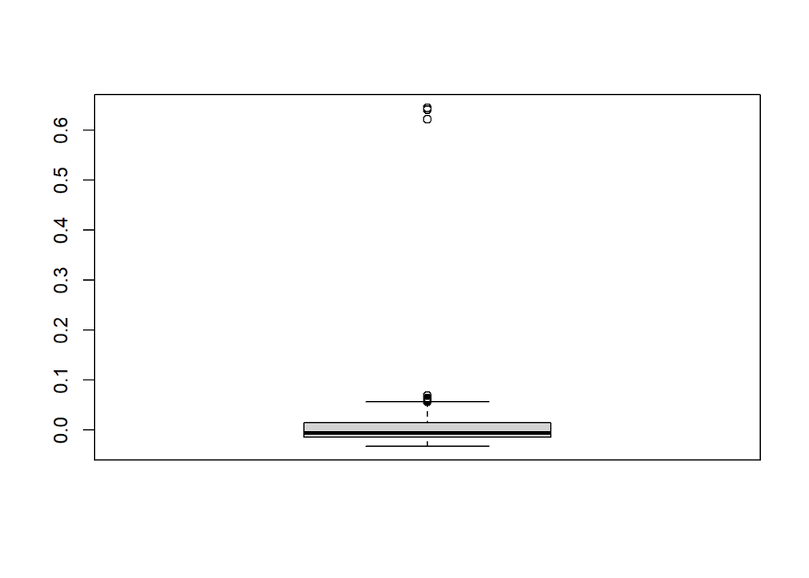

```r
boxplot(time_val$resid)
```

# 5 Conclusion

It would be better if we had substantive context (domain knowledge) to understand what these data represent. Still, it seems as though we got fairly good prediction on this model, despite the presence of some anomalous data.

Perhaps tuning the (p, d, q) hyperparameters would improve the model fit. The auto.arima function is supposed to find the optimal AIC/BIC, but perhaps it can get stuck in a local minimum.

Another idea would be to build an LSTM model to see if the fit can be improved.